# Project 5

STATS 220 Semester One 2023

Joy Zhu

2023-06-09

## Introduction

I selected China, Japan, and South Korea’s Top 100 playlist because those are the country of music I listen to most often these days. While working on this project I was hoping to find the difference in album lengths between different Asian countries. I chose to research this, because I like to listen to whole albums, instead of shuffled songs while studying, so I wanted to figure out which ones are the longest for my longer study sessions.

If we wanted to extract the songs that were in two playlists using SQL, we would do the following:

```sql
SELECT *
  FROM tbl_playlist1
    INNER JOIN tbl_playlist2
      ON tbl_playlist1.song_id = tbl_playlist2.song_id
```

In this SQL code, we use the INNER JOIN function with ON, which selects items with matching song_id keys from both tables.

## Data Creations

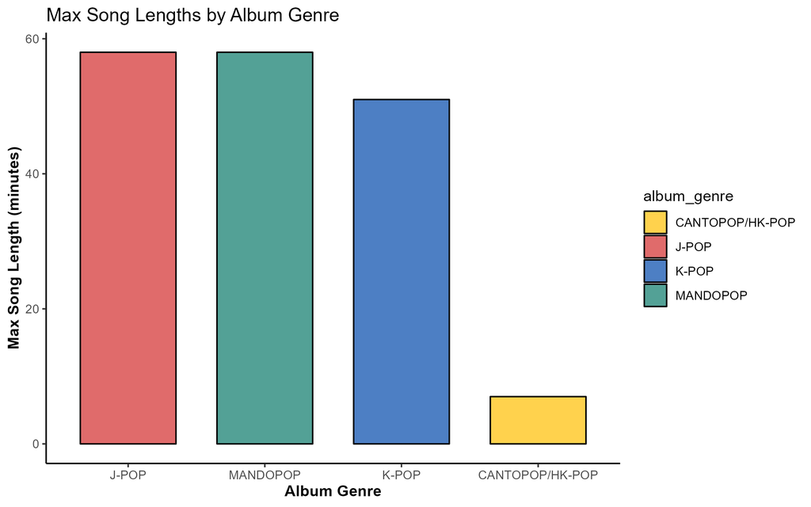

I noticed that the genre “CANTOPOP/HK-POP” bar is much lower then the rest. This is because the genre is not that common, and the only songs in the top 100 are singles, so the max length is only the length of the longest songs. So from this chart I can conclude that J-POP and MANDO-POP albums will be the best for my long study sessions.

[figure not shown]

This animation compares the longest albums of each year, between each genre. It seems that the length of albums varies quite a bit between years, however like the previous graph, CANTOPOP is always on the bottom. It also takes a while for K-POP to show up, this might be because this genre only gained a lot of popularity recently, so older K-POP songs aren’t in the top 100.

I used the gganimate library to create an animation. I used `transition_reveal` which makes previous data persist between frames, so that I can show multiple bars at once instead of having them flicker like if I used `transistion_time`

I chose to go year by year, because if I used an exact date, there would be too many different frames, and it’s unlikely for songs in multiple genres to be released on the exact same dates.

## Final Reflection

One important idea I have learnt from module 5 is that working with data from digital sources often involve inconsistent, missing values and formats which I had experienced while doing this project, and through data filtering, and manipulation I am able to get more accurate data that I want to work with.

Throughout this course I have worked on various projects and have learnt a lot of new things, such as learning way to manipulate data to way we want, guidelines on designing good forms and collecting data that are only necessary to our data researches, additionally the importance of using static and dynamic visualizations to help gain insight on the data which tells us a story/relationship. This course has sparked my curiosity further to explore more advanced topics in data science such as other languages besides R.

## Appendix

```r
library(tidyverse)
library(rvest)

#My countries Top 100 playlist
nz <- "https://music.apple.com/us/playlist/top-100-newzealand/pl.d8742df90f43402ba5e708eefd6d949a"
south_korea <- "https://music.apple.com/us/playlist/top-100-south-korea/pl.d3d10c32fbc540b38e266367dc8cb00c"
china <- "https://music.apple.com/us/playlist/top-100-china/pl.fde851dc95ce4ffbb74028dfd254ced5"
japan <- "https://music.apple.com/us/playlist/top-100-japan/pl.043a2c9876114d95a4659988497567be"

# Function to scrape track IDs
track_id <- function(html) {
  html %>%
    html_elements(".songs-list") %>%
    html_elements("a") %>%
    html_attr("href") %>%
    .[str_detect(., "/song/")] %>%
    str_remove_all("https://(.*)/song/(.*)/")
}

# Function to scrape album IDs
album_id <- function(html) {
  html %>%
    html_elements(".songs-list__col.songs-list__col--tertiary") %>%
    html_elements(".songs-list__song-link-wrapper") %>%
    html_elements("a") %>%
    html_attr("href") %>%
    str_remove_all("https://(.*)/album/(.*)/")
}

# Function to scrape country names
country_name <- function(html) {
  html %>%
    html_element(".headings__title") %>%
    html_text2() %>%
    str_replace("Top 100: ", "")
}

# Function to scrape rankings
ranking <- function(html) {
  html %>%
    html_elements(".songs-list-row__rank") %>%
    html_text2()
}

# Function to scrape song names
song_name <- function(html) {
  html %>%
    html_elements(".songs-list-row__song-name") %>%
    html_text2()
}

# Function to scrape artist names
artist_name <- function(html) {
  html %>%
    html_elements(".songs-list-row__by-line") %>%
    html_text2()
}

# Function to scrape song lengths
song_length <- function(html) {
  html %>%
    html_elements(".songs-list-row__length") %>%
    html_text2() %>%
    str_remove_all("PREVIEW") %>%
    str_remove_all("\n")
}

#data frame from scraped data
dataframe <- function(html) {
  tibble(
    Track_ID = track_id(html),
    Album_ID = album_id(html),
    Country = country_name(html),
    Ranking = ranking(html),
    Song_Name = song_name(html),
    Artist_Name = artist_name(html),
    Song_Length = song_length(html)
  )
}

#combine into a single data frame
song_data <- bind_rows(
  dataframe(read_html(south_korea)),
  dataframe(read_html(china)),
  dataframe(read_html(japan))
)

song_data

saveRDS(song_data, "song_data.rds")
```

```r
library(tidyverse)
library(rvest)

song_data <- readRDS("song_data.rds")

album_ids <- song_data$Album_ID %>% unique()

album_data <- map_df(1: length(album_ids), function(i){
  print(paste("Scraping", i, sep=" "))
  Sys.sleep(2)
  url <- paste0("https://music.apple.com/album/", album_ids[i])

  #handles errors and skips the current album is theres an error retrieving the HTML content
  page <- tryCatch(read_html(url), error = function(e) { NA })
  if (is.na(page))  {
    return (NULL)
  }

  album_info <- page %>%
    html_elements(".footer-body") %>%
    html_elements(".description") %>%
    html_text() %>%
    str_split("\n") %>%
    unlist()

  #Number of songs in an album
  album_song_count <- str_extract(album_info[2], "\\d+")

  #total song length in the album
  album_length <- str_extract(album_info[2], "\\d+ minutes")

  #release date
  album_release_date <- album_info[1] %>%
    mdy()
  album_id = album_ids[i]

  #get the genres in the album
  album_genre <- page %>%
    html_elements(".headings__metadata-bottom") %>%
    html_text() %>%
    str_split(" · ") %>%
    unlist() %>%
    first()

  #get the albums name
  album_name <- page %>%
    html_elements(".headings__title") %>%
    html_text()

  #storing the extracted album info
  album_info <- tibble(
    album_release_date = album_release_date,
    Album_ID = album_ids[i],
    album_song_count = album_song_count,
    album_length = album_length,
    album_genre = album_genre,
    album_name = album_name)

  return (album_info)
})

#if the album is a single or not (1 or more songs)
album_data <- album_data %>%
  mutate(Single =  ifelse(album_song_count == 1, "Yes", "No"))

playlist_data <- inner_join(song_data, album_data, by = "Album_ID")

saveRDS(playlist_data, "playlist_data.rds")
```

```r
library(tidyverse)
library(ggplot2)
library(gganimate)
library(lubridate)
library(stringr)

playlist_data <- readRDS("playlist_data.rds")

playlist_data$album_length <- parse_number(playlist_data$album_length)

# Filter the data from album genre to ones I want such as Cantopop/HK-Pop, J-Pop, and K-Pop genres
filtered_data <- playlist_data %>%
  filter(str_to_lower(album_genre) %in% c("cantopop/hk-pop", "j-pop", "k-pop", "mandopop"))

# Convert album length to time format
filtered_data$album_length <- hms::as_hms(filtered_data$album_length)

# Calculate the maximum song length for each genre in my filtered data
genre_song_lengths <- filtered_data %>%
  group_by(album_genre) %>%
  summarise(max_length = max(album_length, na.rm = TRUE)) %>%
  arrange(desc(max_length))

colours <- c("#FFBF00", "#D22B2B", "#0047AB", "#097969")

# Creating my static plot
my_plot <- ggplot(genre_song_lengths, aes(x = reorder(album_genre, -max_length), y = max_length, fill = album_genre)) +
  geom_bar(stat = "identity", color = "#000000", alpha = 0.7, width = 0.7) +
  scale_fill_manual(values = colours) +
  labs(
    title = "Max Song Lengths by Album Genre",
    x = "Album Genre",
    y = "Max Song Length (minutes)") +
  theme_classic() +
  theme(axis.title = element_text(face = "bold")) +
  theme(axis.title.x = element_text(face = "bold")) +
  theme(axis.title.y = element_text(face = "bold"))

# Rotating the x-axis labels for better readability and aesthetics
my_plot + theme(axis.text.x = element_text(angle = 45, hjust = 1))

ggsave("song_vis.png", my_plot, width = 8, height = 5, units = "in")

genre_song_lengths_time <- filtered_data %>%
  mutate(year = year(album_release_date)) %>%  # extract the year
  group_by(album_genre, year) %>%
  summarise(max_length = max(album_length)) %>%
  arrange(year, desc(max_length))

# Creating my animated plot
animated_plot <- ggplot(genre_song_lengths_time, aes(x = reorder(album_genre, -max_length), y = max_length, fill = album_genre)) +
  geom_bar(stat = "identity", color = "#000000", alpha = 0.7, width = 0.7) +
  scale_fill_manual(values = colours) +
  labs(
    title = "Max Song Lengths by Album Genre Over Time",
    x = "Album Genre",
    y = "Max Song Length (minutes)") +
  theme_classic() +
  theme(axis.title = element_text(face = "bold")) +
  theme(axis.title.x = element_text(face = "bold")) +
  theme(axis.title.y = element_text(face = "bold")) +
  transition_reveal(year) + # using reveal keeps the previous bars
  ease_aes('linear') # smoothly transition bars

# Save the animation as a GIF file
anim_save("song_length_animation.gif", animated_plot)
```